# Catalyzing Police Activity in Seattle 2023

Chloe White, Marykate Buscher, Kaddijatou Baldeh

2024-06-04

# Abstract

The role of policing in communities has long been a topic of discussion, especially since the protests and rallies regarding policing erupted in 2020. Seattle was one of the many cities that experienced these protests. Research on police activity in Seattle is crucial since patterns can be determined, allowing policymakers and criminal justice experts to identify necessary policies and reforms. This study aims to identify patterns regarding arrests, stops, and calls in Seattle reporting districts for 2023. An additional goal of this study is to identify patterns regarding racial demographics within stops and arrests made by the Seattle Police Department in 2023. To answer these questions, the primary method used was the k-means clustering analysis. A cluster map was created to allow for geographical relationships to be identified. As for identifying patterns between police activity and racial demographics, comparisons were made between rates and population. The study found that downtown Seattle had significantly higher arrests, stops, and calls than other areas. Additional results include significantly higher arrest and stop rates among Black and African Americans compared to their population rate. Discussions need to be facilitated on the police presence in downtown Seattle and the disproportionate police involvement with Black and African Americans.

# Introduction

For many decades now, the role of policing in communities has been a topic for discussion among many. Since 2020 especially, the effectiveness of the police in their communities has been under a microscope for many cities and towns. In 2020, protests and rallies erupted all over the United States in response to police brutality and unjust practices of policing. In Seattle, Washington, the autonomous zone in the Capital Hill neighborhood was in place for just shy of a month. Being a part of the police force in any community is a tough job, and no one is taking that away from the officers. Still, questions remain on whether the methods and systems in place are working efficiently and allowing police officers to fulfill their mission of protecting and serving all community members.

Police officers have implicit biases like all humans, but what is more astounding is that the methods of policing also have bias built into them. Biases like racial bias, class bias, and gender bias. No community or police force is without flaw within the United States. The Urban Institute conducted research within the city of Los Angeles, California. Their research focused on the patterns of policing within the city in hopes of supplying important information to the conversations of change within the police force and their role within the community.

Centered in Seattle, Washington, this research aims to gain insight into the patterns of arrests, calls, and stops for 2023. It is modeled after the research done by the Urban Institute, with the same hopes of bringing important information to the conversation within the City of Seattle. Our research aims to identify patterns of police activity within racial demographics and geographic regions in 2023.

Even before the events of 2020, the city knew that the trust between the police and the community was something to be worked on. Multiple chiefs have tried to make it a primary goal during their time in charge to help increase positive relationships between the police officers and the Seattle communities. Chief O’Toole specifically has been known to have made a great impact on the Seattle Police Department and the community (Leadership for a Networked World, 2019). Recently, the “Before the Badge” program has been implemented. This is an eight-week-long training course to help police cadets learn the culture around Seattle (Green, 2022). In turn, the city hopes that the training program and other changes within their crowd control, reducing the use of force, and a change to how they respond to behavioral and mental health calls will improve not only the efficiency of the department as a whole but also increase equity and equality in terms of arrests and stops (DOJ, 2023).

# Methods

### Data and Key Indicators

The data needed for this study were policing data and population data for Seattle. Data on population was collected from the United States Census Bureau and Policing data was collected from the City of Seattle Police Department.

##### Policing Data

The most current full year of data available at the time of this study is 2023. Using data across multiple years would complicate the cluster analysis. Therefore, data was pulled for only 2023. Data was aggregated by reporting district, so our study was focused on reporting districts in 2023. In 2023 there were 18,531 arrests, 339,678 calls, and 4,060 stops. There are 27 variables in the arrests data set, 13 in the calls data set, and 23 in the stop data set. Variables in these data sets include officer, subject, and offense information.

To look at police activity by Seattle reporting districts, we grouped and summarized data on arrests, calls, and stops by beats to get the total number of each. This newly created data set was then used to calculate arrest, call, and stop rates. To calculate these rates, we divided the number of arrests, stops, and calls for each reporting district by the total number of arrests, stops, and calls in the year. Since there are many more calls than arrests and stops, the arrest, stop, and call rates were standardized using the centers.

Additional rates were calculated to look at police activity and race. Rates were calculated for arrests and stops by race. These rates were calculated by dividing the number of people of a given race stopped or arrested by the total number of stops and arrests in Seattle. To compare these with Seattle demographics, population rates by race were calculated by dividing the number of people of a given race by the total population in Seattle. It is important to note that the data used did not report anyone stopped or arrested who was reported as Hispanic. The races included in the data set are White, Black and African American, American Indian or Alaskan Native, Asian, and Native Hawaiian or Other Pacific Islander. Police Officers report races so errors could be made or there could be policies that are not disclosed. Documentation was not provided on why Hispanics were not reported in the data set.

##### Demographic Data

Data was pulled from the United States Census Bureau to gain access to Seattle’s demographic information. The 2020 Census was used since it is the closest year available to the 2023 policing data. Data was gathered from the Census on Seattle’s population and population by race. Since the Census does not collect data based on Reporting Districts, the cluster analysis did not include the population. The data was used strictly to determine the relationship between the subject’s race and police activity.

### Analysis Method

To create classifications of police activity in Seattle, we conducted a cluster analysis of reporting districts based on the number of arrests, calls, and stops. Relationships become clearer and easier to identify when similar data points are grouped together. These relationships can be less apparent when examining data points individually. The clusters created maximize the similarities of observations in the same group while highlighting the differences between groups. This analysis method will allow us to draw conclusions between similar reporting districts geographically and grouped variables.

There are a few different clustering methods. The tool used for this cluster analysis is Tableau which utilizes k-means clustering. K-means clustering groups data points together by looking at their midpoints. This method created clusters where the items in the clusters are similar while the broader groupings are distinct. Using the cluster analysis, we explored the variation in police activity in reporting districts across Seattle.

### Limitations

Our study has a couple of data and methodological limitations. One concern about the SPD data is that it was collected and reported by police officers and emergency dispatchers. When data is collected and reported by humans, there is the potential for biases, inconsistencies, and errors. It is important to consider these potential issues when making conclusions from our analyses. Another limitation of our study is the lack of more demographic data used in the cluster analysis. Since SPD data is categorized by beats and demographic data was not this created challenges in adding demographic metrics to the cluster analysis. Gathering demographic data at the beat level could create a better picture of police activity in Seattle. Finally, since the analysis method used was clustering, this limited the focus of the study to only 2023. Additional studies on Seattle police activity spanning multiple years would allow for analysis of how arrests, stops, and crimes in various areas have changed over time.

# Results

### Table 1

##### Cluster Information

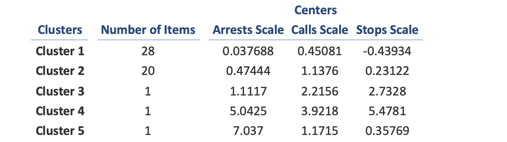

Table 2 demonstrates the differences in means of the variables when looking at the different clusters. Each variable (arrests, stops, and calls) has a significantly low p-value. The low p-values allow us to conclude that the means in each of the clusters are statistically significant. This means that each cluster is distinct in terms of arrests, stops, and calls. The information provided in the analysis of variance (ANOVA) table allows us to conclude that are clustering is valid.

### Table 2

##### Analysis of Variance

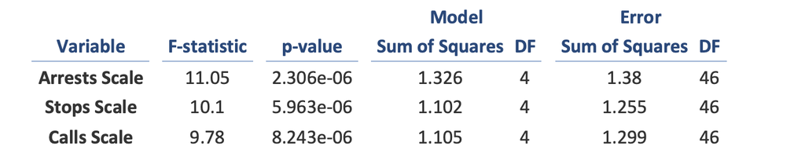

### Figure 1

##### Seattle 2023 Police Activity Cluster Map

[figure not shown]

### Figure 2

##### Seattle 2023 Rates By Race

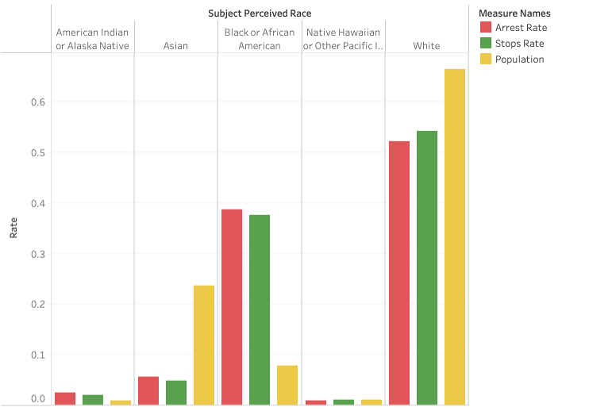

# Discussion

The Seattle Police Department has an impact on the community every second of every day. There is not a minute that goes by where there is not a single police officer on duty. Their impact is not insignificant, and the actions of the officers are all influenced by their training, protocols, and general thoughts about what a “good officer” does and looks like. Within our deep dive of possible patterns something worth pointing out is that clusters four and five (the most severe clusters) are in the general downtown area. This pattern of downtown areas having the most police activity could be due to the fact that this is also where most people are during the day. This can be also true for other cities within the United States. Downtown areas attract the most people because of workplaces, tourist attractions, and general things to do on nice days or days off. More people mean more chances for incidents regardless of their nature. In addition to the many tourists and everyday workers, there is a large congregation of homeless individuals in the downtown area. Cluster 5 stands out due to its large number of arrests with significantly lower numbers of stops and calls. Potential reasoning for what is going on in Cluster 5 is that there could be a large police presence due to the high number of homeless individuals gathering in the area. If an incident is going on in the area involving the homeless, other citizens are unlikely to call and police officers will not need to stop the person to see what is going on. Therefore, the officer would go straight to the arrest.

When focusing on racial demographic patterns within our research analysis, it was found that white people have the most arrests and stops. This aligns with the fact that within Seattle, white is also the highest racial demographic category, accounting for about 65% of the population. While that finding is no surprise, the finding of the rates that those who are black are being arrested and stopped when compared with the percentage of the population they account for is something to look at. Those who are black only account for about 10% of Seattle’s population, yet the rate at which they are arrested and stopped is about 0.35 meaning they account for about 35% of all stops and arrests. This analysis is startling at first, but when put into the context of the historical aspect of policing and black populations, it is not necessarily surprising. This is an example of the embedded racism and prejudice within the policing system and the overall culture of not only Seattle, Washington but also of the United States. One last pattern that was found was within the Asian population in Seattle. While those who identify as Asian account for approximately 25% of the population, they only account for about 5% of all stops and arrests. Something that comes to mind when seeing these numbers is the idea of the model minority. The myth of the model minority is the stereotype that America’s Asian population are examples of high success and high achieving within academic and economic aspects of life when compared with other minority groups (Ruiz, Im, & Tian, 2023). This stereotype is pervasive within American culture and can have real impacts and outcomes one of which could be seen within this pattern of arrests and stops.

Our research aimed to find patterns within the Seattle community regarding policing. Within our research, multiple patterns were found when looking at race demographics, and geographic regions for the city of Seattle and our data. Through our analyses, we found notable patterns that were statistically significant.

# Applications

This research can be used to help facilitate conversations about police activity and police reform. It can also be used to analyze recent patterns of police activity within Seattle and asses the possible progress that may have been made within the year 2023. With the findings of this research, we hope that insight can be gained into the patterns of policing and help guide the discussions in directions that are helpful and productive for the well-being of everyone within a community.

# Conclusion

Police departments and their activity within their communities have been the subject of conversation for some time now. This research performed an analysis of the patterns of police activity within the city of Seattle, Washington in 2023. Our research resulted in patterns that reflect both geographic and racial categories. There is a long history of racial disparities connected with police activities and despite recent efforts to try and mitigate it, there are still issues within the over-policing of certain racial categories. Our findings with geographic pattern reveal that reporting districts downtown have higher police activity when compared to other reporting districts that tend to lean more residential focused within the city itself.

The history of the police department and the overall history of classism and racism within the greater culture all impact police activity and have been more of a focused point for new initiatives for training and protocols within the police department itself. This research acts as a microscope focusing on one city that is like many other American cities like Los Angeles where a similar study was done by the Urban Institute. The findings in this study are indicative of not only the culture of the city of Seattle but also are in alignment with the greater culture of the United States of America. The impact the police department has on not only communities like Seattle, but also the individuals who reside in and visit them is undeniable and should be a focus point for reform movements.

# Appendix

### Figure A.1

##### Seattle 2023 Arrest Rates

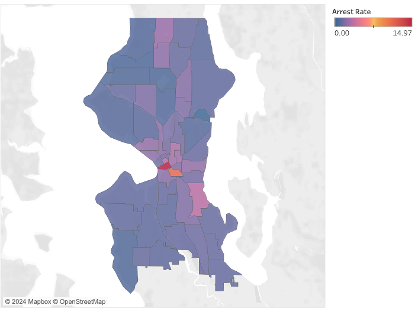

### Figure A.2

##### Seattle 2023 Stop Rates

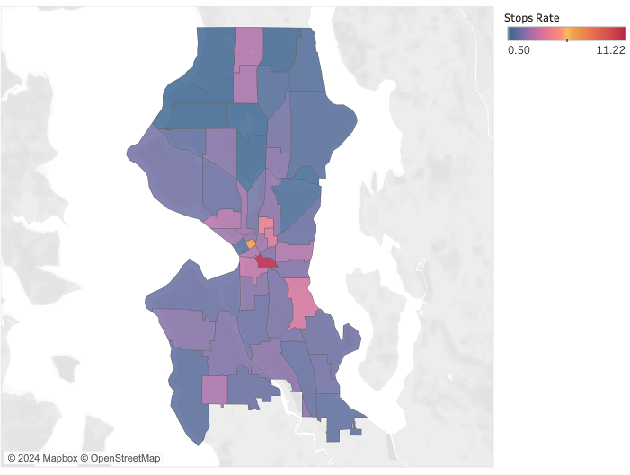

### Figure A.3

##### Seattle 2023 Call Rates

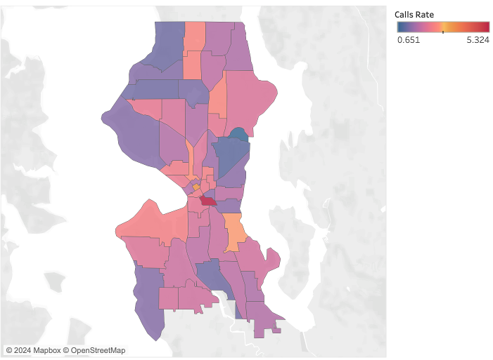

# References

### Data Sources

1. Arrest data: https://data.seattle.gov/Public-Safety/SPD-Arrest-Data/9bjs-7a7w/about_data
2. Stop data: https://data.seattle.gov/Public-Safety/Terry-Stops/28ny-9ts8/about_data
3. Call data: https://data.seattle.gov/Public-Safety/Call-Data/33kz-ixgy/about_data
4. Census: https://data.census.gov/all?q=seattle

### Literature and Current Policing Information

1. Justice Department announces significant milestone in policing reform efforts for the city of Seattle and Seattle Police Department. Office of Public Affairs | Justice Department Announces Significant Milestone in Policing Reform Efforts for the City Of Seattle and Seattle Police Department | United States Department of Justice. (2023, March 29). https://www.justice.gov/opa/pr/justice-department-announces-significant-milestone-policing-reform-efforts-city-seattle-and
2. Neil G. Ruiz, C. I. and Z. T. (2023, November 30). 3. Asian Americans and the “model minority” stereotype. Pew Research Center. https://www.pewresearch.org/2023/11/30/asian-americans-and-the-model-minority-stereotype/
3. Police1. (2022, October 4). Seattle recruits to learn about culture, history of communities they serve during new training. Police1. https://www.police1.com/police-training/articles/seattle-recruits-to-learn-about-culture-history-of-communities-they-serve-during-new-training-XpU9OwFDhScgg3Hg/
4. Rebuilding Trust and value: The transformation of the Seattle Police Department: Leadership for a networked world. Rebuilding Trust and Value: The Transformation of the Seattle Police Department | Leadership for a Networked World. (n.d.). https://lnwprogram.org/content/rebuilding-trust-and-value-transformation-seattle-police-department